# ABC Beverage Company PH Predictors

Chafiaa Nadour, Darwhin Gomez, John Ledesma, NFN TENZIN DAKAR, Puja Roy, Will Jasmine

2024-12-09

# ABC Beverage Company

**Introduction and Abstract**

In response to new regulations requiring ABC Beverage to better understand our manufacturing process and predictive factors for PH levels, our data science team analyzed historical production data to build a reliable forecasting model. The goal was to identify the key factors influencing PH and create accurate predictions to support compliance and process optimization.

**Methodology**

We started by cleaning the data, addressing missing values, removing duplicates, and encoding categorical variables. Numerical features were standardized to ensure consistency. For exploratory data analysis, we visualized the data, checked for outliers, and analyzed correlations between features.

Next, we trained and tested several models including linear regression, decision trees, neural networks, random forests, K-Nearest Neighbors (KNN), and Support Vector Machines (SVM). Model performance was evaluated using RMSE and R-squared metrics.

**Final Model and Key Findings**

## Packages and Setup

```r
library(tidyverse)
library(dplyr)
library(readxl)
library(caret)
```

```r
library(ggcorrplot)
library(gridExtra)
library(janitor)
library(nnet)
library(fastshap)
library(ggplot2)
library(reshape2)
library(randomForest)
library(rpart)
set.seed(12345)
knitr::opts_chunk$set(
  warning = FALSE,
  message = FALSE,
  echo = TRUE,
  fig.width = 8,
  fig.height = 6
)
```

## Data Cleaning

```r
# Load the specific sheet from the first Excel file
training_data <- read_excel("StudentData.xlsx", sheet = "Subset")

# Load the specific sheet from the second Excel file
testing_data <- read_excel("StudentEvaluation.xlsx", sheet = "Subset (2)")
```

```r
# right away, remove any observations with no PH value.

training_data <-training_data[!is.na(training_data[['PH']]), ]

X <- select(training_data, -PH)
y <- training_data$PH

# no PH values are provided in studentEvaluation.xlsx, so we cannot use it
# for testing. We can only use it to make predictions.
```

```r
eval_X <- select(testing_data, -PH)
eval_X <- eval_X %>% drop_na()
```

```r
# Inspect the structure of the data
glimpse(X)
```

```
## Rows: 2,567
## Columns: 32
## $ `Brand Code`        <chr> "B", "A", "B", "A", "A", "A", "A", "B", "B", "B", …
## $ `Carb Volume`       <dbl> 5.340000, 5.426667, 5.286667, 5.440000, 5.486667, …
## $ `Fill Ounces`       <dbl> 23.96667, 24.00667, 24.06000, 24.00667, 24.31333, …
## $ `PC Volume`         <dbl> 0.2633333, 0.2386667, 0.2633333, 0.2933333, 0.1113…
## $ `Carb Pressure`     <dbl> 68.2, 68.4, 70.8, 63.0, 67.2, 66.6, 64.2, 67.6, 64…
## $ `Carb Temp`         <dbl> 141.2, 139.6, 144.8, 132.6, 136.8, 138.4, 136.8, 1…
## $ PSC                 <dbl> 0.104, 0.124, 0.090, NA, 0.026, 0.090, 0.128, 0.15…
## $ `PSC Fill`          <dbl> 0.26, 0.22, 0.34, 0.42, 0.16, 0.24, 0.40, 0.34, 0.…
## $ `PSC CO2`           <dbl> 0.04, 0.04, 0.16, 0.04, 0.12, 0.04, 0.04, 0.04, 0.…
## $ `Mnf Flow`          <dbl> -100, -100, -100, -100, -100, -100, -100, -100, -1…
## $ `Carb Pressure1`    <dbl> 118.8, 121.6, 120.2, 115.2, 118.4, 119.6, 122.2, 1…
## $ `Fill Pressure`     <dbl> 46.0, 46.0, 46.0, 46.4, 45.8, 45.6, 51.8, 46.8, 46…
## $ `Hyd Pressure1`     <dbl> 0, 0, 0, 0, 0, 0, 0, 0, 0, 0, 0, 0, 0, 0, 0, 0, 0,…
```

[output cut: 19 more lines]

```r
glimpse(eval_X)
```

```
## Rows: 200
## Columns: 32
## $ `Brand Code`        <chr> "A", "B", "B", "A", "A", "B", "B", "B", "C", "B", …
## $ `Carb Volume`       <dbl> 5.393333, 5.293333, 5.406667, 5.480000, 5.406667, …
## $ `Fill Ounces`       <dbl> 23.95333, 23.92000, 24.20000, 23.93333, 23.92000, …
## $ `PC Volume`         <dbl> 0.2266667, 0.3033333, 0.1600000, 0.2433333, 0.3326…
## $ `Carb Pressure`     <dbl> 63.2, 66.4, 69.4, 65.2, 66.8, 63.2, 65.0, 63.8, 64…
## $ `Carb Temp`         <dbl> 135.0, 140.4, 142.2, 134.6, 138.0, 139.6, 138.8, 1…
## $ PSC                 <dbl> 0.042, 0.068, 0.040, 0.088, 0.246, 0.184, 0.152, 0…
## $ `PSC Fill`          <dbl> 0.22, 0.10, 0.30, 0.14, 0.48, 0.26, 0.12, 0.18, 0.…
## $ `PSC CO2`           <dbl> 0.08, 0.02, 0.06, 0.00, 0.04, 0.20, 0.00, 0.02, 0.…
## $ `Mnf Flow`          <dbl> -100, -100, -100, -100, -100, -100, -100, -100, -1…
## $ `Carb Pressure1`    <dbl> 118.8, 120.2, 115.0, 117.6, 136.0, 117.2, 117.0, 1…
## $ `Fill Pressure`     <dbl> 46.2, 45.8, 51.4, 46.2, 43.8, 46.2, 45.8, 46.4, 46…
## $ `Hyd Pressure1`     <dbl> 0, 0, 0, 0, 0, 0, 0, 0, 0, 0, 0, 0, 0, 0, 0, 0, 0,…
```

[output cut: 19 more lines]

```r
# Check for missing values
sum(is.na(X))
```

```
## [1] 812
```

```r
sum(is.na(eval_X))
```

```
## [1] 0
```

```r
# View a summary of the data
summary(X)
```

```
##   Brand Code         Carb Volume     Fill Ounces      PC Volume
##  Length:2567        Min.   :5.040   Min.   :23.63   Min.   :0.07933
##  Class :character   1st Qu.:5.293   1st Qu.:23.92   1st Qu.:0.23933
##  Mode  :character   Median :5.347   Median :23.97   Median :0.27133
##                     Mean   :5.370   Mean   :23.97   Mean   :0.27724
##                     3rd Qu.:5.453   3rd Qu.:24.03   3rd Qu.:0.31200
##                     Max.   :5.700   Max.   :24.32   Max.   :0.47800
##                     NA's   :10      NA's   :38      NA's   :39
##  Carb Pressure     Carb Temp          PSC             PSC Fill
##  Min.   :57.00   Min.   :128.6   Min.   :0.00200   Min.   :0.0000
##  1st Qu.:65.60   1st Qu.:138.4   1st Qu.:0.04800   1st Qu.:0.1000
##  Median :68.20   Median :140.8   Median :0.07600   Median :0.1800
##  Mean   :68.19   Mean   :141.1   Mean   :0.08464   Mean   :0.1953
##  3rd Qu.:70.60   3rd Qu.:143.8   3rd Qu.:0.11200   3rd Qu.:0.2600
##  Max.   :79.40   Max.   :154.0   Max.   :0.27000   Max.   :0.6200
##  NA's   :27      NA's   :26      NA's   :33        NA's   :23
##     PSC CO2           Mnf Flow       Carb Pressure1  Fill Pressure
##  Min.   :0.00000   Min.   :-100.20   Min.   :105.6   Min.   :34.60
##  1st Qu.:0.02000   1st Qu.:-100.00   1st Qu.:119.0   1st Qu.:46.00
##  Median :0.04000   Median :  70.20   Median :123.2   Median :46.40
##  Mean   :0.05644   Mean   :  24.63   Mean   :122.6   Mean   :47.92
##  3rd Qu.:0.08000   3rd Qu.: 140.80   3rd Qu.:125.4   3rd Qu.:50.00
##  Max.   :0.24000   Max.   : 229.40   Max.   :140.2   Max.   :60.40
##  NA's   :39                          NA's   :32      NA's   :18
##  Hyd Pressure1   Hyd Pressure2   Hyd Pressure3   Hyd Pressure4
##  Min.   :-0.80   Min.   : 0.00   Min.   :-1.20   Min.   : 62.00
##  1st Qu.: 0.00   1st Qu.: 0.00   1st Qu.: 0.00   1st Qu.: 86.00
##  Median :11.40   Median :28.60   Median :27.60   Median : 96.00
##  Mean   :12.46   Mean   :20.99   Mean   :20.48   Mean   : 96.31
##  3rd Qu.:20.20   3rd Qu.:34.60   3rd Qu.:33.40   3rd Qu.:102.00
##  Max.   :58.00   Max.   :59.40   Max.   :50.00   Max.   :142.00
##  NA's   :11      NA's   :15      NA's   :15      NA's   :28
##   Filler Level    Filler Speed   Temperature      Usage cont      Carb Flow
##  Min.   : 55.8   Min.   : 998   Min.   :63.60   Min.   :12.08   Min.   :  26
##  1st Qu.: 98.3   1st Qu.:3888   1st Qu.:65.20   1st Qu.:18.36   1st Qu.:1166
##  Median :118.4   Median :3982   Median :65.60   Median :21.79   Median :3030
##  Mean   :109.3   Mean   :3688   Mean   :65.96   Mean   :20.99   Mean   :2472
##  3rd Qu.:120.0   3rd Qu.:3998   3rd Qu.:66.40   3rd Qu.:23.75   3rd Qu.:3188
##  Max.   :161.2   Max.   :4030   Max.   :76.20   Max.   :25.90   Max.   :5104
##  NA's   :16      NA's   :54     NA's   :12      NA's   :5       NA's   :2
```

[output cut: 9 more lines]

```
##  Min.   :0.00240   Min.   : 70.0   Min.   :44.00     Min.   :140.8
##  1st Qu.:0.02200   1st Qu.:100.0   1st Qu.:46.00     1st Qu.:142.2
##  Median :0.03340   Median :120.0   Median :46.00     Median :142.6
##  Mean   :0.04643   Mean   :109.3   Mean   :47.61     Mean   :142.8
##  3rd Qu.:0.06000   3rd Qu.:120.0   3rd Qu.:50.00     3rd Qu.:143.0
##  Max.   :0.40000   Max.   :140.0   Max.   :52.00     Max.   :148.2
##  NA's   :11        NA's   :2       NA's   :12
##     Alch Rel        Carb Rel      Balling Lvl
##  Min.   :5.280   Min.   :4.960   Min.   :0.000
##  1st Qu.:6.540   1st Qu.:5.340   1st Qu.:1.380
##  Median :6.560   Median :5.400   Median :1.480
##  Mean   :6.898   Mean   :5.437   Mean   :2.052
##  3rd Qu.:7.240   3rd Qu.:5.550   3rd Qu.:3.140
##  Max.   :8.620   Max.   :6.060   Max.   :3.660
##  NA's   :7       NA's   :8       NA's   :1
```

```r
summary(eval_X)
```

```
##   Brand Code         Carb Volume     Fill Ounces      PC Volume
##  Length:200         Min.   :5.147   Min.   :23.75   Min.   :0.09867
##  Class :character   1st Qu.:5.287   1st Qu.:23.92   1st Qu.:0.23467
##  Mode  :character   Median :5.343   Median :23.97   Median :0.27533
##                     Mean   :5.367   Mean   :23.97   Mean   :0.27681
##                     3rd Qu.:5.453   3rd Qu.:24.01   3rd Qu.:0.32150
##                     Max.   :5.633   Max.   :24.20   Max.   :0.46400
##  Carb Pressure     Carb Temp          PSC             PSC Fill
##  Min.   :60.20   Min.   :130.0   Min.   :0.00400   Min.   :0.0200
##  1st Qu.:65.55   1st Qu.:138.6   1st Qu.:0.04200   1st Qu.:0.1200
##  Median :67.80   Median :140.8   Median :0.07600   Median :0.1800
##  Mean   :68.15   Mean   :141.2   Mean   :0.08157   Mean   :0.1857
##  3rd Qu.:70.05   3rd Qu.:143.4   3rd Qu.:0.10450   3rd Qu.:0.2400
##  Max.   :77.40   Max.   :154.0   Max.   :0.24600   Max.   :0.5600
##     PSC CO2          Mnf Flow       Carb Pressure1  Fill Pressure
##  Min.   :0.0000   Min.   :-100.20   Min.   :113.0   Min.   :43.60
##  1st Qu.:0.0200   1st Qu.:-100.00   1st Qu.:119.4   1st Qu.:46.00
##  Median :0.0400   Median : 107.50   Median :123.4   Median :48.00
##  Mean   :0.0519   Mean   :  31.25   Mean   :122.7   Mean   :48.37
##  3rd Qu.:0.0600   3rd Qu.: 144.10   3rd Qu.:125.2   3rd Qu.:50.20
##  Max.   :0.2400   Max.   : 199.00   Max.   :136.0   Max.   :54.80
##  Hyd Pressure1   Hyd Pressure2  Hyd Pressure3   Hyd Pressure4
##  Min.   : 0.00   Min.   : 0.0   Min.   : 0.00   Min.   : 72.00
##  1st Qu.: 0.00   1st Qu.: 0.0   1st Qu.: 0.00   1st Qu.: 89.50
##  Median :11.90   Median :30.7   Median :30.30   Median : 96.00
##  Mean   :13.35   Mean   :23.8   Mean   :23.09   Mean   : 95.15
##  3rd Qu.:21.00   3rd Qu.:35.4   3rd Qu.:34.60   3rd Qu.:100.50
##  Max.   :45.40   Max.   :61.4   Max.   :49.20   Max.   :128.00
##   Filler Level     Filler Speed   Temperature     Usage cont      Carb Flow
##  Min.   : 69.20   Min.   :1008   Min.   :63.8   Min.   :14.04   Min.   :1048
##  1st Qu.: 99.35   1st Qu.:3898   1st Qu.:65.4   1st Qu.:18.11   1st Qu.:2692
##  Median :113.80   Median :3984   Median :65.8   Median :21.67   Median :3066
##  Mean   :108.28   Mean   :3851   Mean   :65.9   Mean   :21.09   Mean   :2659
##  3rd Qu.:119.85   3rd Qu.:3996   3rd Qu.:66.4   3rd Qu.:23.79   3rd Qu.:3245
##  Max.   :137.00   Max.   :4020   Max.   :71.6   Max.   :24.34   Max.   :3824
##     Density           MFR           Balling      Pressure Vacuum
##  Min.   :0.460   Min.   : 95.0   Min.   :1.048   Min.   :-6.400
##  1st Qu.:0.920   1st Qu.:709.0   1st Qu.:1.498   1st Qu.:-5.600
##  Median :0.980   Median :726.0   Median :1.648   Median :-5.400
##  Mean   :1.185   Mean   :707.0   Mean   :2.219   Mean   :-5.229
##  3rd Qu.:1.620   3rd Qu.:731.5   3rd Qu.:3.290   3rd Qu.:-5.000
##  Max.   :1.840   Max.   :784.8   Max.   :3.788   Max.   :-3.600
##  Oxygen Filler     Bowl Setpoint   Pressure Setpoint Air Pressurer
##  Min.   :0.00240   Min.   : 70.0   Min.   :44.00     Min.   :141.2
##  1st Qu.:0.01570   1st Qu.:100.0   1st Qu.:46.00     1st Qu.:142.2
##  Median :0.03350   Median :120.0   Median :48.00     Median :142.6
##  Mean   :0.04585   Mean   :108.6   Mean   :47.87     Mean   :142.8
##  3rd Qu.:0.05440   3rd Qu.:120.0   3rd Qu.:50.00     3rd Qu.:142.8
##  Max.   :0.35400   Max.   :130.0   Max.   :52.00     Max.   :147.2
##     Alch Rel       Carb Rel      Balling Lvl
##  Min.   :6.40   Min.   :5.220   Min.   :1.260
##  1st Qu.:6.54   1st Qu.:5.340   1st Qu.:1.380
##  Median :6.58   Median :5.400   Median :1.460
##  Mean   :6.89   Mean   :5.435   Mean   :2.056
##  3rd Qu.:7.16   3rd Qu.:5.540   3rd Qu.:3.080
##  Max.   :7.82   Max.   :5.740   Max.   :3.420
```

```r
head(X)
```

```
## # A tibble: 6 × 32
##   `Brand Code` `Carb Volume` `Fill Ounces` `PC Volume` `Carb Pressure`
##   <chr>                <dbl>         <dbl>       <dbl>           <dbl>
## 1 B                     5.34          24.0       0.263            68.2
## 2 A                     5.43          24.0       0.239            68.4
## 3 B                     5.29          24.1       0.263            70.8
## 4 A                     5.44          24.0       0.293            63
## 5 A                     5.49          24.3       0.111            67.2
## 6 A                     5.38          23.9       0.269            66.6
## # ℹ 27 more variables: `Carb Temp` <dbl>, PSC <dbl>, `PSC Fill` <dbl>,
## #   `PSC CO2` <dbl>, `Mnf Flow` <dbl>, `Carb Pressure1` <dbl>,
## #   `Fill Pressure` <dbl>, `Hyd Pressure1` <dbl>, `Hyd Pressure2` <dbl>,
## #   `Hyd Pressure3` <dbl>, `Hyd Pressure4` <dbl>, `Filler Level` <dbl>,
## #   `Filler Speed` <dbl>, Temperature <dbl>, `Usage cont` <dbl>,
## #   `Carb Flow` <dbl>, Density <dbl>, MFR <dbl>, Balling <dbl>,
## #   `Pressure Vacuum` <dbl>, `Oxygen Filler` <dbl>, `Bowl Setpoint` <dbl>, …
```

```r
head(eval_X)
```

```
## # A tibble: 6 × 32
##   `Brand Code` `Carb Volume` `Fill Ounces` `PC Volume` `Carb Pressure`
##   <chr>                <dbl>         <dbl>       <dbl>           <dbl>
## 1 A                     5.39          24.0       0.227            63.2
## 2 B                     5.29          23.9       0.303            66.4
## 3 B                     5.41          24.2       0.16             69.4
## 4 A                     5.48          23.9       0.243            65.2
## 5 A                     5.41          23.9       0.333            66.8
## 6 B                     5.26          24.1       0.22             63.2
## # ℹ 27 more variables: `Carb Temp` <dbl>, PSC <dbl>, `PSC Fill` <dbl>,
## #   `PSC CO2` <dbl>, `Mnf Flow` <dbl>, `Carb Pressure1` <dbl>,
## #   `Fill Pressure` <dbl>, `Hyd Pressure1` <dbl>, `Hyd Pressure2` <dbl>,
## #   `Hyd Pressure3` <dbl>, `Hyd Pressure4` <dbl>, `Filler Level` <dbl>,
## #   `Filler Speed` <dbl>, Temperature <dbl>, `Usage cont` <dbl>,
## #   `Carb Flow` <dbl>, Density <dbl>, MFR <dbl>, Balling <dbl>,
## #   `Pressure Vacuum` <dbl>, `Oxygen Filler` <dbl>, `Bowl Setpoint` <dbl>, …
```

```r
# Remove rows with missing data
y <- y[complete.cases(X)]
X <- X %>% drop_na()

eval_X <- eval_X %>% drop_na()
```

```r
# Standardize column names
X <- X %>% rename_all(tolower) %>%
  rename_all(gsub, pattern = " ", replacement = "_")
eval_X <- eval_X %>% rename_all(tolower) %>%
  rename_all(gsub, pattern = " ", replacement = "_")
```

```r
# remove duplicates
X <- X %>% distinct()
eval_X <- eval_X %>% distinct()
```

```r
# remove the columns that only have 1 unique value

single_value_cols <- sapply(X, function(col) length(unique(col)) == 1)
X <- X[, !single_value_cols, drop = FALSE]
eval_X <- eval_X[, !single_value_cols, drop = FALSE]
```

```r
missing_train <- sapply(X, function(col) sum(is.na(col)))
missing_test <- sapply(eval_X, function(col) sum(is.na(col)))

print(missing_train)
```

```
##        brand_code       carb_volume       fill_ounces         pc_volume
##                 0                 0                 0                 0
##     carb_pressure         carb_temp               psc          psc_fill
##                 0                 0                 0                 0
##           psc_co2          mnf_flow    carb_pressure1     fill_pressure
##                 0                 0                 0                 0
##     hyd_pressure1     hyd_pressure2     hyd_pressure3     hyd_pressure4
##                 0                 0                 0                 0
##      filler_level      filler_speed       temperature        usage_cont
##                 0                 0                 0                 0
##         carb_flow           density               mfr           balling
##                 0                 0                 0                 0
##   pressure_vacuum     oxygen_filler     bowl_setpoint pressure_setpoint
##                 0                 0                 0                 0
##     air_pressurer          alch_rel          carb_rel       balling_lvl
##                 0                 0                 0                 0
```

```r
print(missing_test)
```

```
##        brand_code       carb_volume       fill_ounces         pc_volume
##                 0                 0                 0                 0
##     carb_pressure         carb_temp               psc          psc_fill
##                 0                 0                 0                 0
##           psc_co2          mnf_flow    carb_pressure1     fill_pressure
##                 0                 0                 0                 0
##     hyd_pressure1     hyd_pressure2     hyd_pressure3     hyd_pressure4
##                 0                 0                 0                 0
##      filler_level      filler_speed       temperature        usage_cont
##                 0                 0                 0                 0
##         carb_flow           density               mfr           balling
##                 0                 0                 0                 0
##   pressure_vacuum     oxygen_filler     bowl_setpoint pressure_setpoint
##                 0                 0                 0                 0
##     air_pressurer          alch_rel          carb_rel       balling_lvl
##                 0                 0                 0                 0
```

```r
# Convert character columns to factors and ensure date columns are correctly formatted
X <- X %>%
  mutate(across(where(is.character), as.factor))

eval_X <- eval_X %>%
  mutate(across(where(is.character), as.factor))
```

```r
# one-hot-encode the brand_code field with dummy variables
encode_var <- function(df, col){
  ohm <- model.matrix(~ . - 1, data = df[, col, drop = FALSE])
  ohm <- as.data.frame(ohm)
  ohm <- lapply(ohm, as.factor)
  return(cbind(df[ , !names(df) %in% col, drop = FALSE], ohm))
}

X <- encode_var(X, 'brand_code')
eval_X <- encode_var(eval_X, 'brand_code')
```

```r
# Data types
str(X)
```

```
## 'data.frame':    2038 obs. of  35 variables:
##  $ carb_volume      : num  5.49 5.38 5.25 5.27 5.32 ...
##  $ fill_ounces      : num  24.3 23.9 24 24 23.9 ...
##  $ pc_volume        : num  0.111 0.269 0.263 0.231 0.259 ...
##  $ carb_pressure    : num  67.2 66.6 64.2 72 66.2 61.6 71.6 72.6 68 63.8 ...
##  $ carb_temp        : num  137 138 140 147 139 ...
##  $ psc              : num  0.026 0.09 0.132 0.014 0.078 0.11 0.096 0.16 0.034 0.124 ...
##  $ psc_fill         : num  0.16 0.24 0.12 0.24 0.18 ...
##  $ psc_co2          : num  0.12 0.04 0.14 0.06 0.04 ...
##  $ mnf_flow         : num  -100 -100 -100 -100 -100 -100 -100 -100 -100 -100 ...
##  $ carb_pressure1   : num  118 120 121 120 120 ...
##  $ fill_pressure    : num  45.8 45.6 46 45.2 46.6 46.6 46 46.6 47.4 48.8 ...
##  $ hyd_pressure1    : num  0 0 0 0 0 0 0 0 0 0 ...
##  $ hyd_pressure2    : num  0 0 0 0 0 0 0 0 0 0 ...
##  $ hyd_pressure3    : num  0 0 0 0 0 0 0 0 0 0 ...
```

[output cut: 21 more lines]

## EDA

The cell below creates a function that can be used to count the number of outliers in each column of a dataframe:

```r
count_outliers <- function(dataframe) {
  outlier_counts <- sapply(dataframe, function(column) {
    if (is.numeric(column)) {
      Q1 <- quantile(column, 0.25, na.rm = TRUE)
      Q3 <- quantile(column, 0.75, na.rm = TRUE)
      IQR <- Q3 - Q1
      lower_bound <- Q1 - 1.5 * IQR
      upper_bound <- Q3 + 1.5 * IQR
      sum(column < lower_bound | column > upper_bound, na.rm = TRUE)
    } else {
      NA
    }
  })
  return(outlier_counts)
}
```

The `count_outliers` function is used below to plot the number of outliers present in each predictor field:

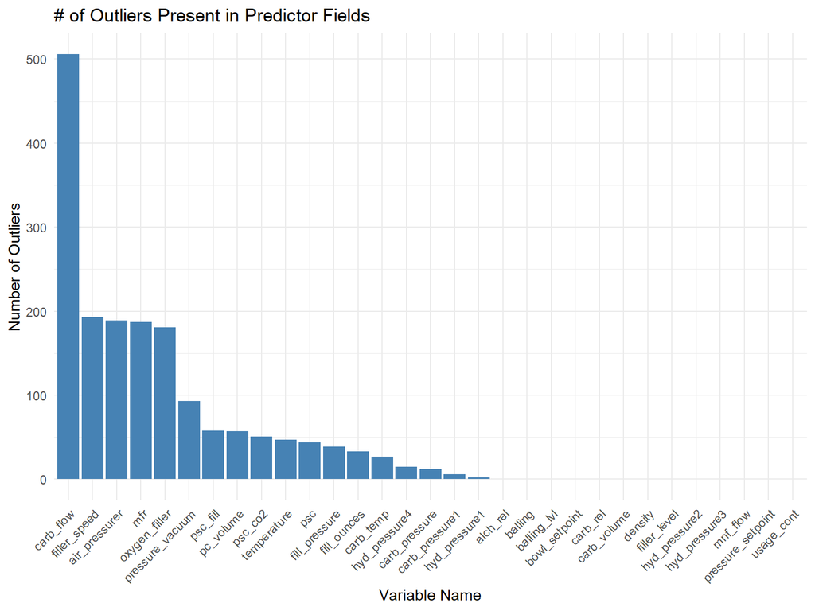

```r
outlier_counts <- count_outliers(X)
outlier_counts <- data.frame(
  Column = names(outlier_counts),
  Outliers = as.numeric(outlier_counts)
)
outlier_counts <- na.omit(outlier_counts)


ggplot(outlier_counts, aes(x = reorder(Column, -Outliers), y = Outliers)) +
  geom_bar(stat = "identity", fill = "steelblue") +
  theme_minimal() +
  labs(
    title = "# of Outliers Present in Predictor Fields",
    x = "Variable Name",
    y = "Number of Outliers"
  ) +
  theme(axis.text.x = element_text(angle = 45, hjust=1))
```

Next, the cell below includes function that tests whether or not each column within the dataframe is normal.

```r
test_normality <- function(dataframe) {
  results <- lapply(dataframe, function(column) {
    if (is.numeric(column)) {
      test_result <- tryCatch(
        shapiro.test(column),
        error = function(e) NULL # handle errors (e.g., small sample size)
      )
      if (!is.null(test_result)) {
        return(data.frame(
          Statistic = test_result$statistic,
          P_Value = test_result$p.value
        ))
      } else {
        return(data.frame(Statistic = NA, P_Value = NA))
      }
    } else {
      # return NA for non-numeric columns
      return(data.frame(Statistic = NA, P_Value = NA))
    }
  })

  # combine results into a dataframe
  results_df <- do.call(rbind, results)
  rownames(results_df) <- names(dataframe)
  return(results_df)
}

normality_results <- test_normality(X)
normality_results
```

```
##                   Statistic      P_Value
## carb_volume       0.9570379 4.605382e-24
## fill_ounces       0.9946490 1.030640e-06
## pc_volume         0.9852127 1.110007e-13
## carb_pressure     0.9964220 9.849891e-05
## carb_temp         0.9960234 3.279974e-05
## psc               0.9547630 1.204310e-24
## psc_fill          0.9393717 4.303840e-28
## psc_co2           0.8376258 1.905078e-41
## mnf_flow          0.7261226 1.232213e-49
## carb_pressure1    0.9866239 7.233734e-13
## fill_pressure     0.8638292 7.322913e-39
## hyd_pressure1     0.9032089 4.276136e-34
## hyd_pressure2     0.7994928 1.168334e-44
## hyd_pressure3     0.8109674 9.495383e-44
## hyd_pressure4     0.9567037 3.769116e-24
## filler_level      0.8375014 1.855578e-41
## filler_speed      0.3512008 8.071603e-65
## temperature       0.9397270 5.074408e-28
## usage_cont        0.8693097 2.854520e-38
## carb_flow         0.7042791 6.671293e-51
## density           0.8204577 5.819635e-43
## mfr               0.4344164 2.904769e-62
## balling           0.7700461 8.205418e-47
## pressure_vacuum   0.9618916 9.729409e-23
## oxygen_filler     0.7951776 5.449870e-45
## bowl_setpoint     0.7916412 2.945908e-45
## pressure_setpoint 0.7390249 7.562504e-49
## air_pressurer     0.7021706 5.082926e-51
## alch_rel          0.7078074 1.055353e-50
## carb_rel          0.9392944 4.152571e-28
## balling_lvl       0.7081517 1.103931e-50
## brand_codeA              NA           NA
## brand_codeB              NA           NA
## brand_codeC              NA           NA
## brand_codeD              NA           NA
```

The cell below produces a correlation matrix to show the correlations between all pairs of predictor variables, helping to assess the level of multicollinearity.

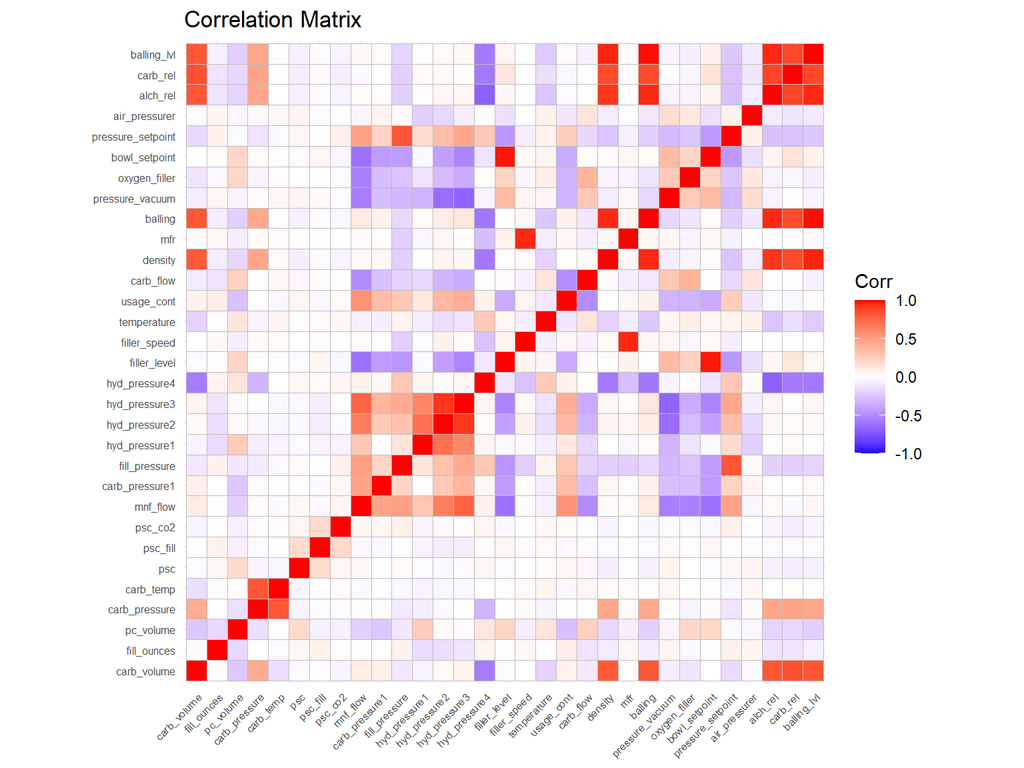

```r
corr_matrix <- cor(select(X, where(is.numeric)))
ggcorrplot(corr_matrix, lab = FALSE, title = "Correlation Matrix") +
  theme(
    axis.text.x = element_text(size = 6),
    axis.text.y = element_text(size = 6)
  )
```

The cell below produces scatterplots of each explanatory field with the predictor variable PH. Each scatterplot includes the correlation coefficent and a best fit line relating the two fields.

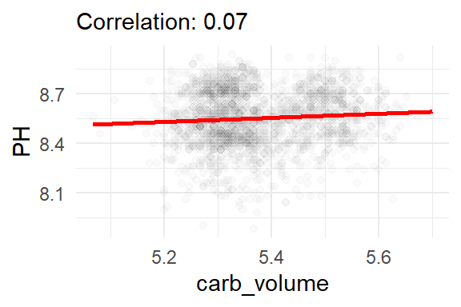

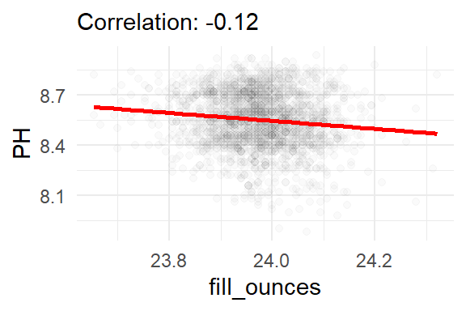

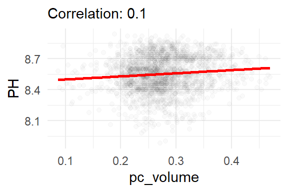

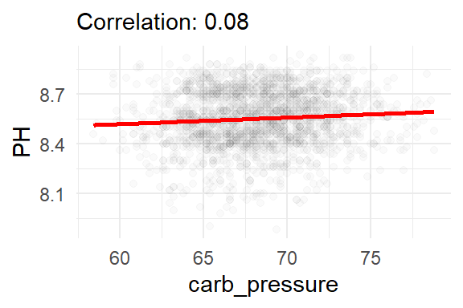

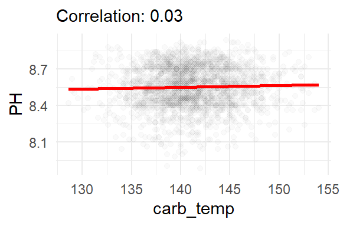

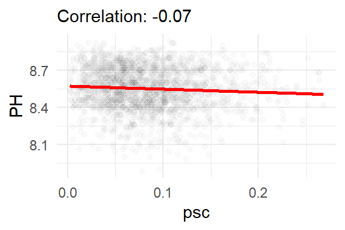

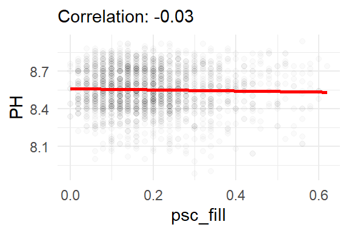

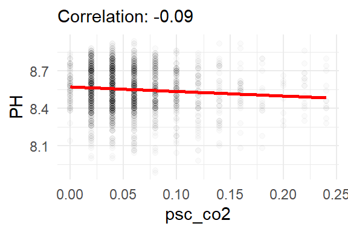

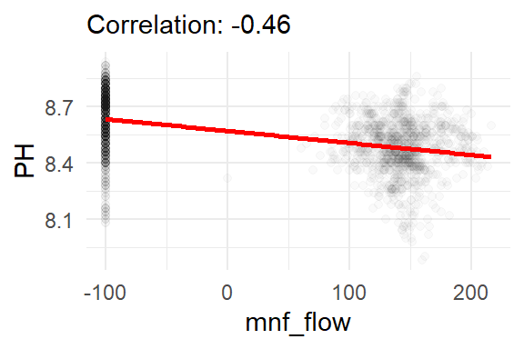

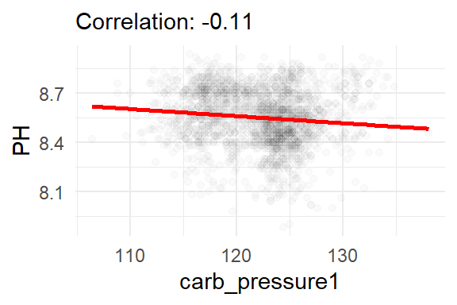

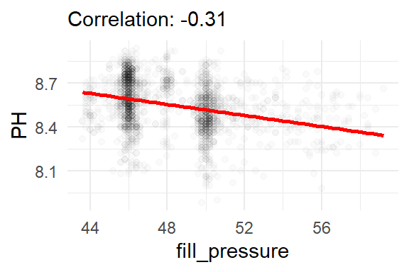

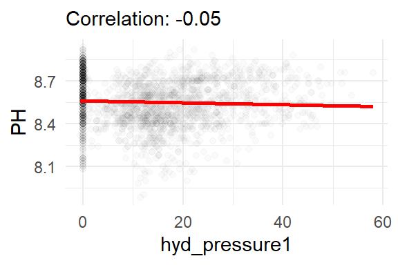

[19 more figures not shown]

```r
plot_scatter_with_fit <- function(X, y) {
  plots <- list()

  for (col in names(X)) {
    correlation <- cor(X[[col]], y)
    plot <- ggplot(data = data.frame(x = X[[col]], y = y), aes(x = x, y = y)) +
      geom_point(alpha=.02) +
      geom_smooth(method = "lm", se = FALSE, color = "red") +
      labs(
        subtitle = paste("Correlation:", round(correlation, 2)),
        x = col,
        y = "PH"
      ) +
      theme_minimal()
    plots[[col]] <- plot
  }

  return(plots)
}

scatter_plots <- plot_scatter_with_fit(select(X, where(is.numeric)), y)

for (plot in scatter_plots) {
  print(plot)
}
```

The cell below plots the distributions of the categorical features in `X`:

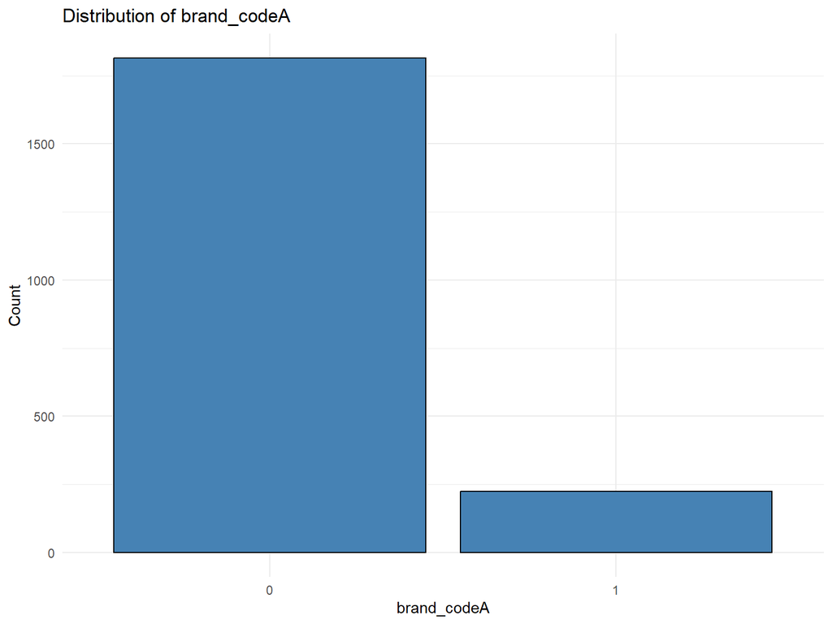

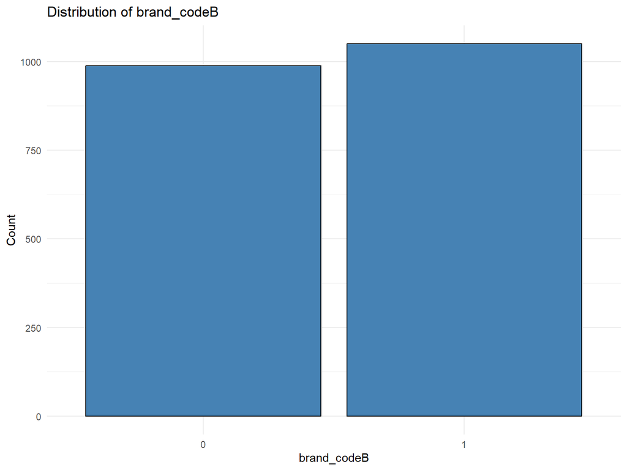

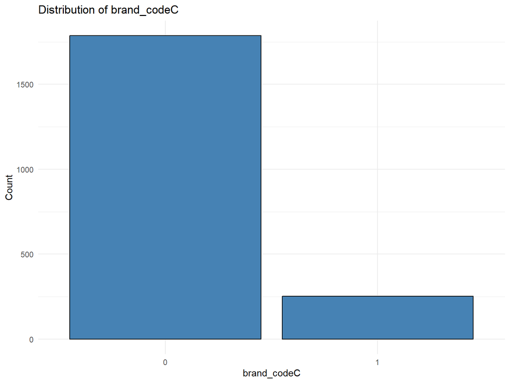

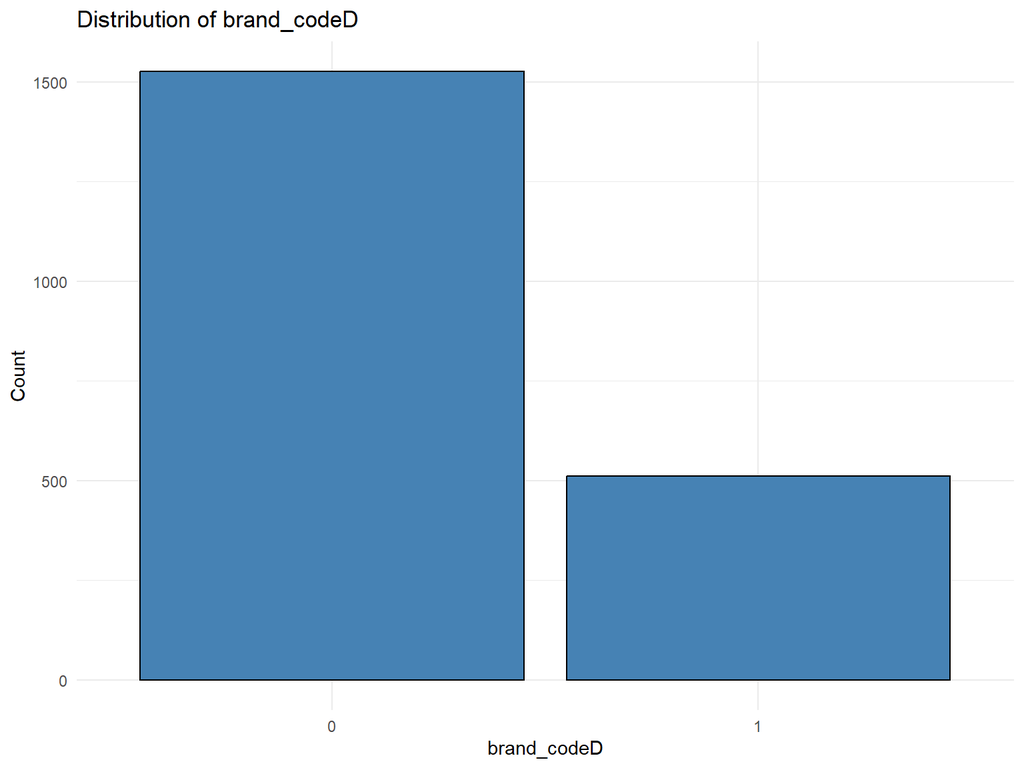

```r
plot_categorical_distributions <- function(df) {
  # Identify categorical columns
  categorical_columns <-
    names(df)[sapply(df, is.factor) | sapply(df, is.character)]

  # Create bar plots for each categorical column
  plots <- lapply(categorical_columns, function(column) {
    ggplot(df, aes_string(x = column)) +
      geom_bar(fill = "steelblue", color = "black") +
      labs(
        title = paste("Distribution of", column),
        x = column,
        y = "Count"
      ) +
      theme_minimal()
  })

  return(plots)
}

cat_plots <- plot_categorical_distributions(select(X, where(is.factor)))

for (plot in cat_plots) {
  print(plot)
}
```

## Data Pre-Processing

Split the data into testing and training sets.

```r
train_index <- createDataPartition(y, p = 0.75, list = FALSE)

X_train <- X[train_index, ]
X_test <- X[-train_index, ]

y_train <- y[train_index]
y_test <- y[-train_index]
```

Apply the Yeo-Johnson transformation.

```r
numeric_features <- sapply(X, is.numeric)

# fit the Yeo-Johnson transformation using training data
preprocess_params <- preProcess(X_train[, numeric_features],
                                method = "YeoJohnson")

# pply the transformation to training and testing data
X_train[, numeric_features] <- predict(preprocess_params,
                                       X_train[, numeric_features])
X_test[, numeric_features] <- predict(preprocess_params,
                                    X_test[, numeric_features])
```

Use robust scaling to scale the data:

```r
# only use medians and iqrs from training data
medians <- apply(X_train[, numeric_features], 2, median)
iqrs <- apply(X_train[, numeric_features], 2, IQR)

# performs the robust scaling using the IQRs and medians
robust_scale <- function(data, medians, iqrs) {
  scaled_data <- sweep(data, 2, medians, "-")
  scaled_data <- sweep(scaled_data, 2, iqrs, "/")
  return(scaled_data)
}

# transform the training and testing data
X_train[, numeric_features] <- robust_scale(X_train[, numeric_features],
                                           medians, iqrs)
X_test[, numeric_features] <- robust_scale(X_test[, numeric_features],
                                          medians, iqrs)
```

Finds all pairs of highly correlated variables ($|r| > 0.7$) and randomly removes one variable from each pair.

```r
high_corr_indices <- findCorrelation(corr_matrix, cutoff = 0.7, names = TRUE)
X_train <- X_train[, !names(X_train) %in% high_corr_indices]
X_test <- X_test[, !names(X_test) %in% high_corr_indices]
```

Make new variables (and update old ones) using the transformed data:

```r
X <- rbind(X_train, X_test)
train <- X_train
train$PH <- y_train
test <- X_test
test$PH <- y_test
```

Check again for outliers:

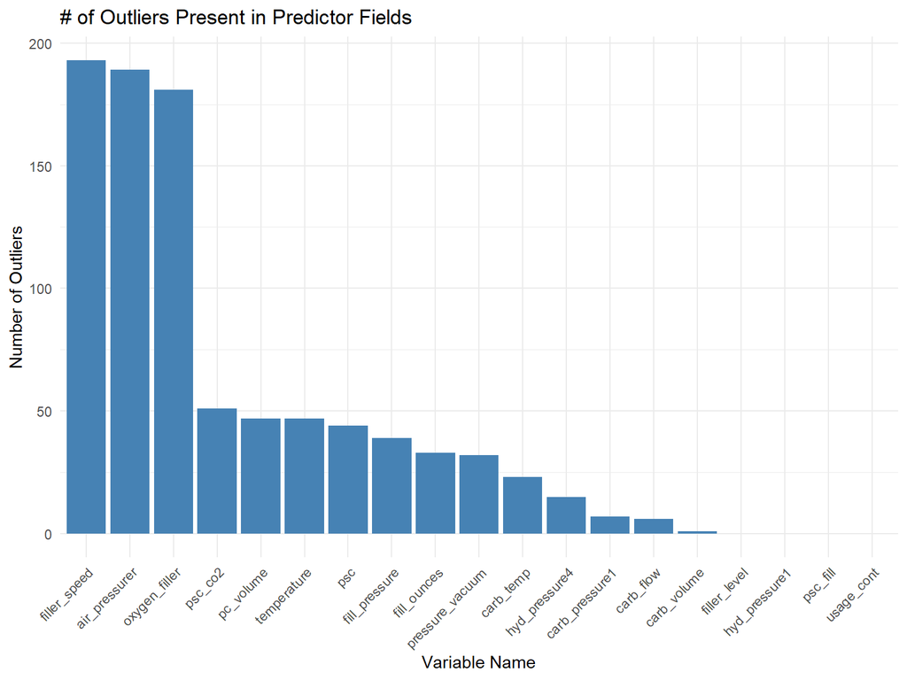

```r
outlier_counts <- count_outliers(X)
outlier_counts <- data.frame(
  Column = names(outlier_counts),
  Outliers = as.numeric(outlier_counts)
)
outlier_counts <- na.omit(outlier_counts)


ggplot(outlier_counts, aes(x = reorder(Column, -Outliers), y = Outliers)) +
  geom_bar(stat = "identity", fill = "steelblue") +
  theme_minimal() +
  labs(
    title = "# of Outliers Present in Predictor Fields",
    x = "Variable Name",
    y = "Number of Outliers"
  ) +
  theme(axis.text.x = element_text(angle = 45, hjust=1))
```

Check again for normal distributions:

```r
normality_results <- test_normality(X)
normality_results
```

```
##                 Statistic      P_Value
## carb_volume     0.9570379 4.605382e-24
## fill_ounces     0.9946490 1.030640e-06
## pc_volume       0.9892472 3.426857e-11
## carb_temp       0.9980432 1.438409e-02
## psc             0.9547630 1.204310e-24
## psc_fill        0.9887001 1.463930e-11
## psc_co2         0.8376258 1.905078e-41
## carb_pressure1  0.9873377 1.961692e-12
## fill_pressure   0.8638292 7.322913e-39
## hyd_pressure1   0.8740895 9.712845e-38
## hyd_pressure4   0.9570190 4.553325e-24
## filler_level    0.8375014 1.855578e-41
## filler_speed    0.3512008 8.071603e-65
## temperature     0.9397270 5.074408e-28
## usage_cont      0.8693097 2.854520e-38
## carb_flow       0.7919069 3.084296e-45
## pressure_vacuum 0.9802522 3.481334e-16
## oxygen_filler   0.7951776 5.449870e-45
## air_pressurer   0.7021706 5.082926e-51
## brand_codeA            NA           NA
## brand_codeB            NA           NA
## brand_codeC            NA           NA
## brand_codeD            NA           NA
```

Check again for multicollinearity:

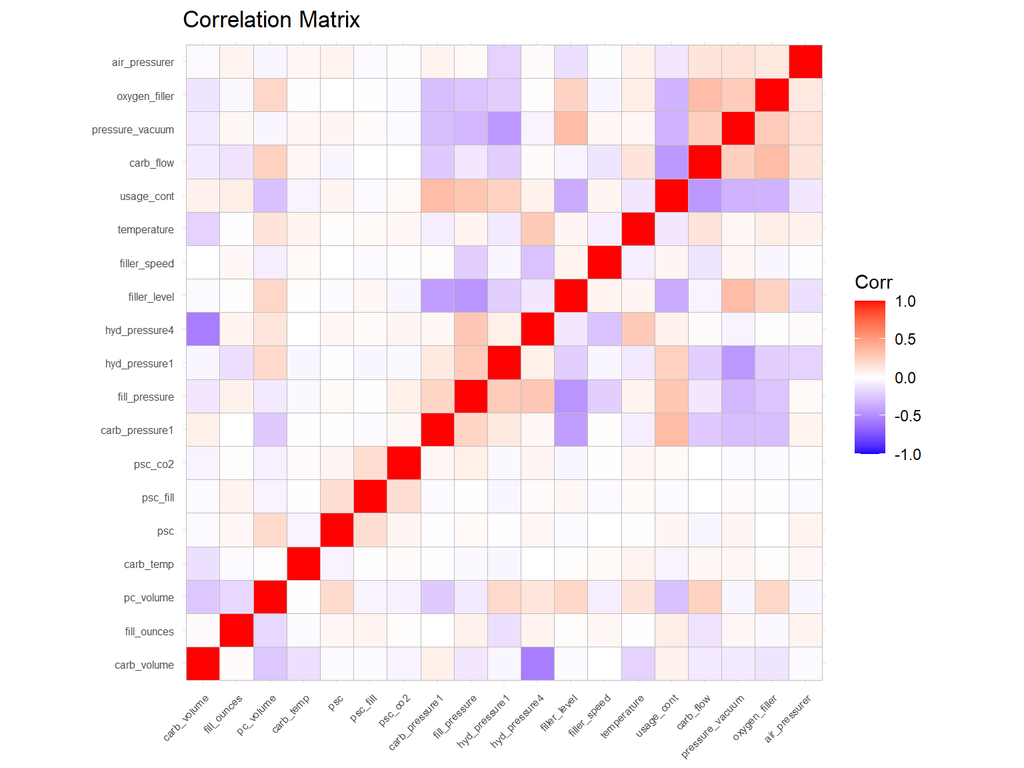

```r
corr_matrix <- cor(select(X, where(is.numeric)))
ggcorrplot(corr_matrix, lab = FALSE, title = "Correlation Matrix") +
  theme(
    axis.text.x = element_text(size = 6),
    axis.text.y = element_text(size = 6)
  )
```

We now have scaled, transformed and removed mutlti collenaer pairs from our data, we can proceed to building models.

## Modeling

The first models used is a simple Linear Regression

```r
model_lm1 <- lm(train$PH ~ ., train)
summary(model_lm1)
```

```
##
## Call:
## lm(formula = train$PH ~ ., data = train)
##
## Residuals:
##      Min       1Q   Median       3Q      Max
## -0.51212 -0.07911  0.01401  0.09560  0.44786
##
## Coefficients: (1 not defined because of singularities)
##                   Estimate Std. Error t value Pr(>|t|)
## (Intercept)      8.6571515  0.0169592 510.468  < 2e-16 ***
## carb_volume     -0.0211829  0.0111656  -1.897  0.05800 .
## fill_ounces     -0.0069887  0.0044412  -1.574  0.11578
## pc_volume       -0.0030710  0.0053001  -0.579  0.56240
## carb_temp       -0.0019803  0.0048417  -0.409  0.68258
## psc             -0.0042448  0.0048281  -0.879  0.37944
## psc_fill        -0.0065565  0.0055376  -1.184  0.23660
## psc_co2         -0.0062008  0.0035136  -1.765  0.07780 .
## carb_pressure1   0.0355027  0.0061499   5.773 9.45e-09 ***
## fill_pressure   -0.0243515  0.0062108  -3.921 9.22e-05 ***
## hyd_pressure1    0.0003830  0.0090633   0.042  0.96630
## hyd_pressure4    0.0074237  0.0078570   0.945  0.34489
## filler_level     0.0979577  0.0090507  10.823  < 2e-16 ***
## filler_speed    -0.0036012  0.0011146  -3.231  0.00126 **
## temperature     -0.0302962  0.0047424  -6.388 2.23e-10 ***
## usage_cont      -0.0601566  0.0083179  -7.232 7.54e-13 ***
## carb_flow        0.0543009  0.0102074   5.320 1.20e-07 ***
## pressure_vacuum  0.0021836  0.0050273   0.434  0.66409
## oxygen_filler    0.0001932  0.0032632   0.059  0.95279
## air_pressurer   -0.0006421  0.0024088  -0.267  0.78985
## brand_codeA1    -0.1031997  0.0173165  -5.960 3.14e-09 ***
## brand_codeB1    -0.0473982  0.0192697  -2.460  0.01402 *
## brand_codeC1    -0.1860677  0.0227281  -8.187 5.66e-16 ***
## brand_codeD1            NA         NA      NA       NA
## ---
## Signif. codes:  0 '***' 0.001 '**' 0.01 '*' 0.05 '.' 0.1 ' ' 1
##
## Residual standard error: 0.1369 on 1506 degrees of freedom
## Multiple R-squared:  0.3715, Adjusted R-squared:  0.3623
## F-statistic: 40.46 on 22 and 1506 DF,  p-value: < 2.2e-16
```

Decision Tree

```r
model_tree1 <- rpart(train$PH ~., data = train)

predict(model_tree1, test)
```

[output not shown]

[output cut: 73 more lines]

[output not shown]

```r
RMSE(predict(model_tree1, test), test$PH)
```

```
## [1] 0.1349601
```

Plotting Tree1

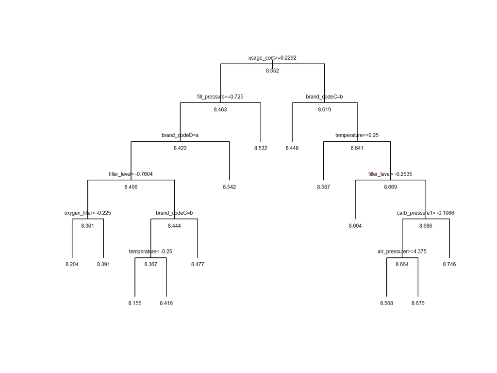

```r
plot(model_tree1, uniform=TRUE, compress=FALSE, margin=.015)
text(model_tree1, all=TRUE, cex=.5)
```

Neural Network

```r
my.grid <- expand.grid(decay = c(0.5,0,1), size=c(5,6,7))

model_nnet <- train(PH ~ ., data=train, method="nnet",
      maxit=500, tuneGrid = my.grid, trace =F, linout = 1)
```

```r
print(model_nnet)
```

```
## Neural Network
##
## 1529 samples
##   23 predictor
##
## No pre-processing
## Resampling: Bootstrapped (25 reps)
## Summary of sample sizes: 1529, 1529, 1529, 1529, 1529, 1529, ...
## Resampling results across tuning parameters:
##
##   decay  size  RMSE       Rsquared   MAE
##   0.0    5     0.2586472  0.3048120  0.12498432
##   0.0    6     0.5222105  0.3000944  0.16361182
##   0.0    7     1.2898967  0.2696562  0.26220503
##   0.5    5     0.1306745  0.4284715  0.10059015
##   0.5    6     0.1305440  0.4299680  0.10004188
##   0.5    7     0.1295583  0.4372411  0.09956567
##   1.0    5     0.1302672  0.4243708  0.10052455
##   1.0    6     0.1301176  0.4256484  0.10037720
##   1.0    7     0.1292306  0.4328996  0.09958846
##
## RMSE was used to select the optimal model using the smallest value.
## The final values used for the model were size = 7 and decay = 1.
```

Random Forest

```r
RMSE(predict(model_nnet, test), test$PH)
```

```
## [1] 0.1250552
```

```r
RMSE(predict(model_tree1, test), test$PH)
```

```
## [1] 0.1349601
```

```r
RMSE(predict(model_lm1, test), test$PH)
```

```
## [1] 0.1351587
```

```r
# Load Necessary Libraries
library(caret)
library(randomForest)



# 1. Combine Features and Target for Training
train$PH <- y_train

# 2. Training the Random Forest Model
rfModel <- randomForest(
  x = train[, setdiff(names(train), "PH")],  # Features (exclude the target variable)
  y = train$PH,                             # Target variable
  importance = TRUE,                        # Enable variable importance
  ntree = 1500                               # Number of trees
)

# 3. Combine Features and Target for Testing
test$PH <- y_test

# 4. Making Predictions on the Test Set
rfPred <- predict(rfModel, test[, setdiff(names(test), "PH")])

# 5. Evaluating Model Performance
testY_vec <- test$PH
performance <- postResample(pred = rfPred, obs = testY_vec)

# Display the Performance Metrics
print(performance)
```

```
##       RMSE   Rsquared        MAE
## 0.10235056 0.65131395 0.07790556
```

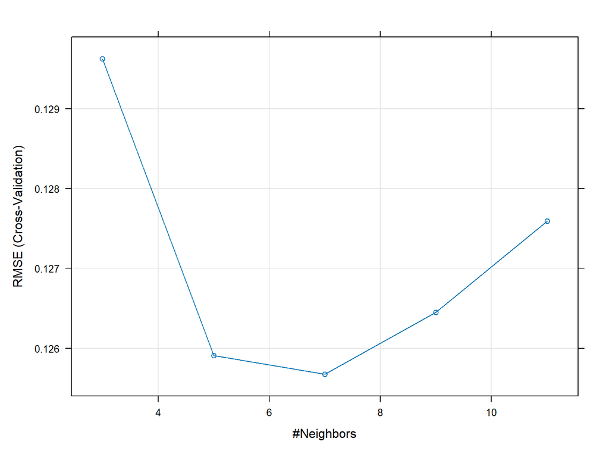

```r
#  Define Cross-Validation Control
train_control <- trainControl(
  method = "cv",
  number = 5,
  verboseIter = FALSE,
  search = "grid"
)

#   Grid of Hyperparameters for k-Values
k_values <- expand.grid(k = c(3, 5, 7, 9, 11))

#  Train the KNN Model

knn_model <- train(
  x = X_train,
  y = y_train,
  method = "knn",
  tuneGrid = k_values,
  trControl = train_control
)

#  Plot the KNN Model Performance
plot(knn_model)
```

```r
# Train SVM with radial kernel
svm_model <- train(
  PH ~ .,
  data = train,
  method = "svmRadial",
  trControl = trainControl(method = "cv", number = 5),
  tuneLength = 5
)
```

```r
svm_model
```

```
## Support Vector Machines with Radial Basis Function Kernel
##
## 1529 samples
##   23 predictor
##
## No pre-processing
## Resampling: Cross-Validated (5 fold)
## Summary of sample sizes: 1224, 1222, 1223, 1223, 1224
## Resampling results across tuning parameters:
##
##   C     RMSE       Rsquared   MAE
##   0.25  0.1277438  0.4614226  0.09552216
##   0.50  0.1255571  0.4780651  0.09325780
##   1.00  0.1232271  0.4946128  0.09145115
##   2.00  0.1218984  0.5040928  0.09088473
##   4.00  0.1216624  0.5062811  0.09097519
##
## Tuning parameter 'sigma' was held constant at a value of 0.02956161
## RMSE was used to select the optimal model using the smallest value.
## The final values used for the model were sigma = 0.02956161 and C = 4.
```

```r
# Predict and evaluate
svm_pred <- predict(svm_model, test)
svm_rmse <- RMSE(svm_pred, test$PH)
svm_r2 <- R2(svm_pred, test$PH)

# Display metrics
cat("SVM Model RMSE:", svm_rmse, "\n")
```

```
## SVM Model RMSE: 0.1113341
```

```r
cat("SVM Model R-Squared:", svm_r2, "\n")
```

```
## SVM Model R-Squared: 0.5731233
```

## Model Analysis and Explanatory features

```r
# Calculate RMSE and R-squared for Neural Network Model
rmse_nnet <- RMSE(predict(model_nnet, test), test$PH)
rsq_nnet <- R2(predict(model_nnet, test), test$PH)

# Calculate RMSE and R-squared for Tree-Based Model
rmse_tree1 <- RMSE(predict(model_tree1, test), test$PH)
rsq_tree1 <- R2(predict(model_tree1, test), test$PH)

# Calculate RMSE and R-squared for Linear Model
rmse_lm1 <- RMSE(predict(model_lm1, test), test$PH)
rsq_lm1 <- R2(predict(model_lm1, test), test$PH)

# Calculate RMSE and R-squared for Random Forest Model
rmse_rf <- RMSE(rfPred, test$PH)
rsq_rf <- R2(rfPred, test$PH)

# Calculate RMSE and R-squared for KNN Model
rmse_knn <- RMSE(predict(knn_model, test), test$PH)
rsq_knn <- R2(predict(knn_model, test), test$PH)


# Create a Data Frame of RMSE and R-squared Values
model_performance <- data.frame(
  Model = c("Neural Network", "Tree-Based", "Linear Model", "Random Forest", "KNN", "SVM"),
  RMSE = c(rmse_nnet, rmse_tree1, rmse_lm1, rmse_rf, rmse_knn,svm_rmse),
  R_Squared = c(rsq_nnet, rsq_tree1, rsq_lm1, rsq_rf, rsq_knn,svm_r2)
)

# Display the Performance Data Frame
model_performance <- model_performance %>%
  arrange(RMSE, desc(R_Squared))

# Print the sorted model_performance data frame
print(model_performance)
```

```
##            Model      RMSE R_Squared
## 1  Random Forest 0.1023506 0.6513140
## 2            SVM 0.1113341 0.5731233
## 3            KNN 0.1187727 0.5122407
## 4 Neural Network 0.1250552 0.4540662
## 5     Tree-Based 0.1349601 0.3675322
## 6   Linear Model 0.1351587 0.3599708
```

After Tuning the different models we conclude that best preforming model is the Random Forrest Model with an R_Squared of 0.65 and RMSE of 0.10

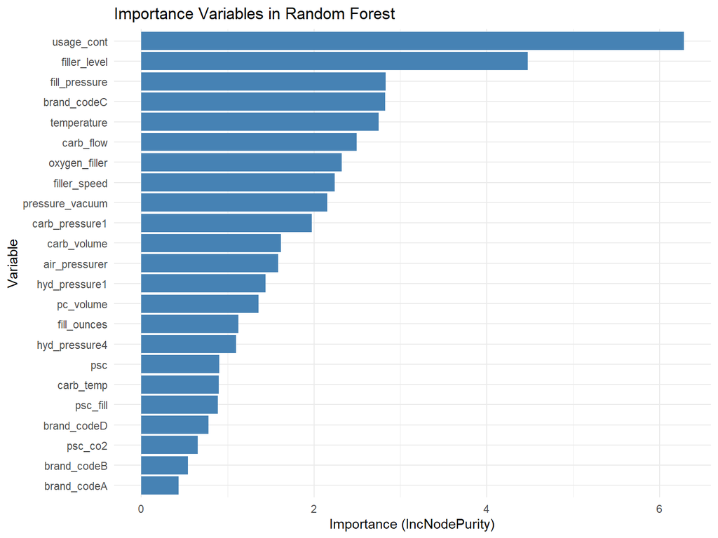

```r
# Extract variable of importance
var_importance <- importance(rfModel)

importance_df <- data.frame(
  Variable = rownames(var_importance),
  Importance = var_importance[, "IncNodePurity"]
)
# Order

importance_df <- importance_df[order(importance_df$Importance, decreasing = TRUE), ]
#ploting


ggplot(importance_df, aes(x = reorder(Variable, Importance), y = Importance)) +
  geom_bar(stat = "identity", fill = "steelblue") +
  coord_flip() +
  labs(title = "Importance Variables in Random Forest",
       x = "Variable",
       y = "Importance (IncNodePurity)") +
  theme_minimal()
```

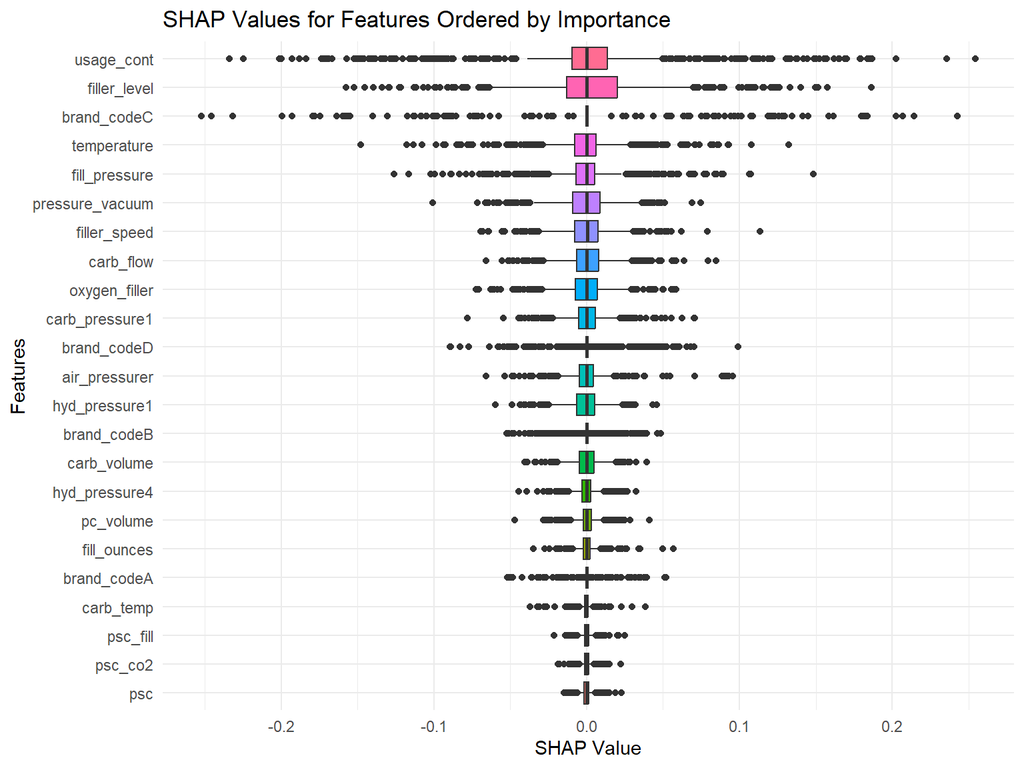

```r
# Define the prediction function for the Random Forest model
pred_wrapper <- function(object, newdata) {
  predict(object, newdata = newdata)
}

# Compute SHAP values for the test set
shap_values <- fastshap::explain(
  object = rfModel,
  X = as.data.frame(test[, -which(names(test) == "PH")]),
  pred_wrapper = pred_wrapper
)

# Convert SHAP values to a data frame
shap_df <- as.data.frame(shap_values)
shap_df$Observation <- 1:nrow(shap_df)

# Calculate mean absolute SHAP values for each feature to determine importance
shap_importance <- colMeans(abs(shap_df[, -ncol(shap_df)]))
shap_importance <- sort(shap_importance, decreasing = TRUE)
ordered_features <- names(shap_importance)

# Melt the SHAP values data frame to long format for ggplot
shap_long <- melt(shap_df, id.vars = "Observation", variable.name = "Feature", value.name = "SHAP")

# Convert Feature to a factor ordered by importance (flipped)
shap_long$Feature <- factor(shap_long$Feature, levels = rev(ordered_features))

# Plot the SHAP values with important features at the top
ggplot(shap_long, aes(x = Feature, y = SHAP, fill = Feature)) +
  geom_boxplot() +
  coord_flip() +
  theme_minimal() +
  labs(title = "SHAP Values for Features Ordered by Importance",
       y = "SHAP Value",
       x = "Features") +
  theme(legend.position = "none")
```

```r
# top num vars for plotting correlations
numerical_vars <- c("usage_cont", "filler_level", "temperature","fill_pressure", "carb_flow")

# Calculate correlation coefficients for numeric variables
correlations <- sapply(numerical_vars, function(var) cor(train[[var]], train$PH, use = "complete.obs"))
print("Correlations of PH and top numerical variables")
```

```
## [1] "Correlations of PH and top numerical variables"
```

```r
correlations
```

```
##    usage_cont  filler_level   temperature fill_pressure     carb_flow
##    -0.3580374     0.3399455    -0.1971432    -0.3304814     0.2047809
```

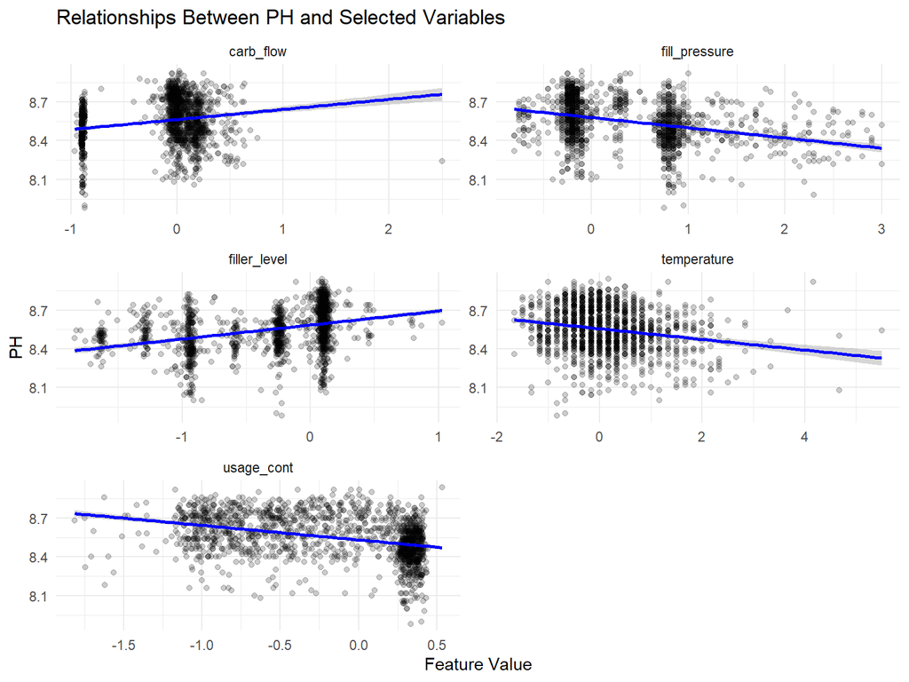

```r
# Select the relevant columns
data_subset <- train[, c("PH", numerical_vars)]

# Pivot the data to long format for faceting
data_long <- pivot_longer(data_subset, cols = all_of(numerical_vars), names_to = "Variable", values_to = "Value")

# Create the facet plot
ggplot(data_long, aes(x = Value, y = PH)) +
  geom_point(alpha = 0.2) +
  geom_smooth(method = "lm", color = "blue", se = TRUE) +
  facet_wrap(~ Variable, scales = "free", ncol = 2) +
  labs(title = "Relationships Between PH and Selected Variables",
       x = "Feature Value",
       y = "PH",
        ) +
  theme_minimal()
```

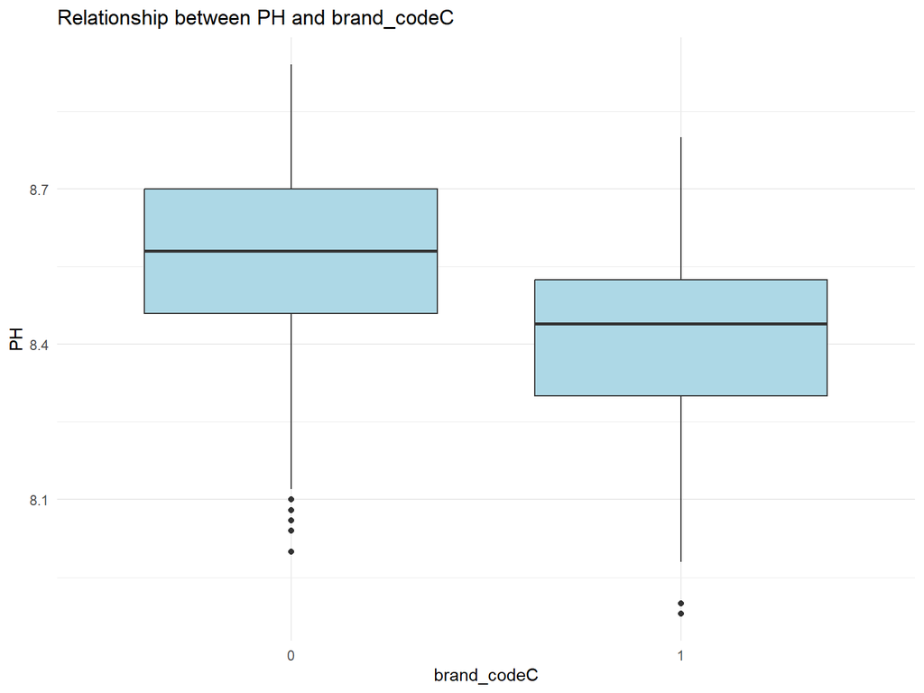

```r
# Boxplot for the categorical variable 'brand_codeC'

ggplot(train, aes(x = as.factor(brand_codeC), y = PH)) +
    geom_boxplot(fill = "lightblue") +
    labs(title = "Relationship between PH and brand_codeC",
         x = "brand_codeC",
         y = "PH") +
    theme_minimal()
```

## Final Thoughts on the Top Variables for Predicting PH

Combining insights from the variable importance plot, SHAP values, and correlation plots, we can make informed conclusions about how our top 5 variables influence the Random Forest model’s predictions for PH:

**usage_cont**

- Importance: Ranked the most important variable in the Random Forest model.
- SHAP Insight: SHAP values show both positive and negative impacts on PH, suggesting variability in its effect.
- Correlation Plot: Shows a negative correlation with PH. Higher usage_cont values lead to lower PH levels.
- Conclusion: usage_cont is a strong predictor, likely capturing flow rate and system efficiency, which impact acidity levels.

**brand_codeC**

- Importance: The fourth most important variable.
- SHAP Insight: SHAP values suggest a strong negative impact when Brand C is present.
- Boxplot: PH is consistently lower when brand_codeC = 1 (Brand C is present).
- Conclusion: The formulation or process used by Brand C leads to lower PH levels compared to other brands.

**carb_flow**

- Importance: The sixth most important variable.
- SHAP Insight: SHAP values show a positive impact on PH.
- Correlation Plot: Displays a slight positive correlation. Higher carb_flow increases PH.
- Conclusion: Carb flow affects the amount of dissolved CO₂, altering acidity and thereby increasing PH.

**Summary of Insights:**

**filler_level** and **carb_flow** exhibit positive influences on **PH**.

**fill_pressure** negatively influences **PH**.

**brand_codeC** distinctly lowers **PH**.

**Conclusion:**

In conclusion, while the Random Forest model is the best performer for predicting PH, we need to be clear about its limitations. The model’s R-squared of 0.65 and RMSE of 0.10 are the best scores among the models we trained and tested. But with 35% of the variance in PH left unexplained, there’s room for improvement.

Future analysis should focus on filling the gaps in the data or applying imputation techniques for missing values. We should also consider adding more features or refining existing ones to capture more of what drives PH levels. Right now, the forecasts are based on a model that doesn’t include imputations, and that’s something stakeholders should keep in mind.

The team is confident in the insights delivered so far, but with more complete data and some adjustments, we can make even better predictions in the future.

## Forecasts

```r
# Ensure preprocessing is applied to eval_X

# Apply Yeo-Johnson transformation to eval_X
eval_X[, numeric_features] <- predict(preprocess_params, eval_X[, numeric_features])

# Apply robust scaling to eval_X
eval_X[, numeric_features] <- robust_scale(eval_X[, numeric_features], medians, iqrs)
```

```r
# Remove highly correlated variables from eval_X
eval_X <- eval_X[, !names(eval_X) %in% high_corr_indices]

# Make predictions on the eval_X dataset using the Random Forest model
eval_predictions <- predict(rfModel, eval_X)

# Display the predicted PH values
print("Predicted PH values:")
```

```
## [1] "Predicted PH values:"
```

```r
print(eval_predictions)
```

```
##        1        2        3        4        5        6        7        8
## 8.531851 8.603143 8.496703 8.523643 8.609380 8.529564 8.556028 8.746530
##        9       10       11       12       13       14       15       16
## 8.328026 8.581438 8.581967 8.601740 8.710108 8.614099 8.597041 8.615836
##       17       18       19       20       21       22       23       24
## 8.487977 8.449442 8.633737 8.682109 8.580535 8.565949 8.553090 8.557087
##       25       26       27       28       29       30       31       32
## 8.674184 8.706720 8.321299 8.387354 8.671264 8.719526 8.701226 8.701277
##       33       34       35       36       37       38       39       40
## 8.641984 8.730761 8.692891 8.761330 8.682994 8.454105 8.516469 8.654464
##       41       42       43       44       45       46       47       48
## 8.755156 8.734625 8.750944 8.735522 8.721475 8.757144 8.571764 8.555226
##       49       50       51       52       53       54       55       56
## 8.575807 8.596961 8.584895 8.496598 8.415022 8.533208 8.555514 8.542948
##       57       58       59       60       61       62       63       64
## 8.502970 8.655768 8.710757 8.693966 8.767340 8.642309 8.626228 8.607960
##       65       66       67       68       69       70       71       72
## 8.708350 8.642886 8.583602 8.706785 8.548307 8.684580 8.632432 8.611212
##       73       74       75       76       77       78       79       80
## 8.601411 8.708010 8.705296 8.748947 8.744084 8.428039 8.459278 8.498614
##       81       82       83       84       85       86       87       88
## 8.644689 8.648746 8.597674 8.671324 8.674667 8.676715 8.683344 8.675282
##       89       90       91       92       93       94       95       96
## 8.610223 8.652668 8.698168 8.601261 8.569489 8.538041 8.521243 8.525146
##       97       98       99      100      101      102      103      104
## 8.573202 8.485654 8.540701 8.476891 8.424081 8.511464 8.505408 8.588440
##      105      106      107      108      109      110      111      112
## 8.575082 8.576334 8.584466 8.527812 8.652756 8.450518 8.465418 8.439398
##      113      114      115      116      117      118      119      120
## 8.490966 8.537927 8.559260 8.626806 8.608619 8.638556 8.717568 8.646098
##      121      122      123      124      125      126      127      128
## 8.701178 8.438174 8.542954 8.535612 8.651901 8.448982 8.535418 8.447995
##      129      130      131      132      133      134      135      136
## 8.399496 8.507557 8.520241 8.471886 8.354592 8.372130 8.547954 8.400976
##      137      138      139      140      141      142      143      144
## 8.382844 8.368475 8.476426 8.457102 8.476027 8.333137 8.339997 8.313790
##      145      146      147      148      149      150      151      152
## 8.318392 8.431888 8.467044 8.450848 8.415168 8.378575 8.487884 8.486926
##      153      154      155      156      157      158      159      160
## 8.348944 8.407049 8.450529 8.468483 8.372240 8.411245 8.367988 8.332852
##      161      162      163      164      165      166      167      168
## 8.545659 8.505944 8.493745 8.492170 8.456895 8.395450 8.555494 8.475673
##      169      170      171      172      173      174      175      176
## 8.449899 8.485641 8.463428 8.485945 8.486793 8.533447 8.525938 8.625628
##      177      178      179      180      181      182      183      184
## 8.634585 8.492647 8.501467 8.468431 8.555540 8.477963 8.438225 8.452320
##      185      186      187      188      189      190      191      192
## 8.456068 8.518920 8.505006 8.445432 8.528754 8.549645 8.559218 8.500270
##      193      194      195      196      197      198      199      200
## 8.509977 8.602137 8.572722 8.470956 8.601771 8.300192 8.352504 8.311770
```

```r
# Add the predictions to the eval_X dataset
eval_X$PH_Predicted <- eval_predictions
```

```r
# Export the dataset with predictions to a new Excel file
write.csv(eval_X, "StudentEvaluation_WithForecasts.csv", row.names = FALSE)

# Confirm export completion
cat("Forecasts successfully generated and exported to 'StudentEvaluation_WithForecasts.csv'.\n")
```

```
## Forecasts successfully generated and exported to 'StudentEvaluation_WithForecasts.csv'.
```